# Time Series 예상문제

SHIN, Eon Seok

2021 8 17

```r
library(fpp2)
library(forecast)
library(tseries)
library(tidyverse)
```

## **시계열 분석 예상문제 및 풀이**

*이 문제는 개인적으로 공부하기 위하여 18회 ADP 기출문제를 참고하여 작성한 문제로 풀이 과정에 오류가 있을수 있습니다.*

문제는 두 문제입니다. 전체적인 풀이 과정은 유사하나, 데이터가 달라 풀이 과정에 약간의 차이가 있습니다. 시계열 데이터 분석을 숙달하기 위해 두가지 문제를 준비했습니다.

#### **문제 I**

호주의 월별 가스 생산량 데이터를 가지고 다음의 지시대로 문제를 해결하시오.  
1. 데이터의 정상성 확인 및 변환  
a) 위 데이터가 정상성을 충족하는지 확인하기 위해 데이터를 플로팅하시오.  
b) 위 데이터를 성분(수준, 추세, 계절성 성분)으로 분해하여 플로팅 하시오.  
c) 정상성을 만족하는지 통계적 검정을 실시하고 결과를 해석하시오.  
d) 정상성을 충족하지 못하면 적절한 변환과정을 거쳐 데이터를 변환하시오.  
2. ARIMA 모형을 적용하기 위하여 다음을 해결하시오.  
a) ACF, PACF 도표를 활용하여 적용 가능한 모형을 제시하시오.  
b) auto.arima를 사용, seasonal 요소를 포함한 모형(SARIMA)을 제시하시오.  
c) 위 b) 모형의 정확도를 제시하시오.  
d) 위 b) 모형에 대한 잔차의 정규성과 자기상관성을 검정하시오.  
3) 위 2번에서 생성된 모형으로가스생산량을 예측하시오.  
a) 2년치 가스 생산량을 예측하시오. b) 예측결과를 그래프로 그려 가시화하시오.  
#——————————————————————————

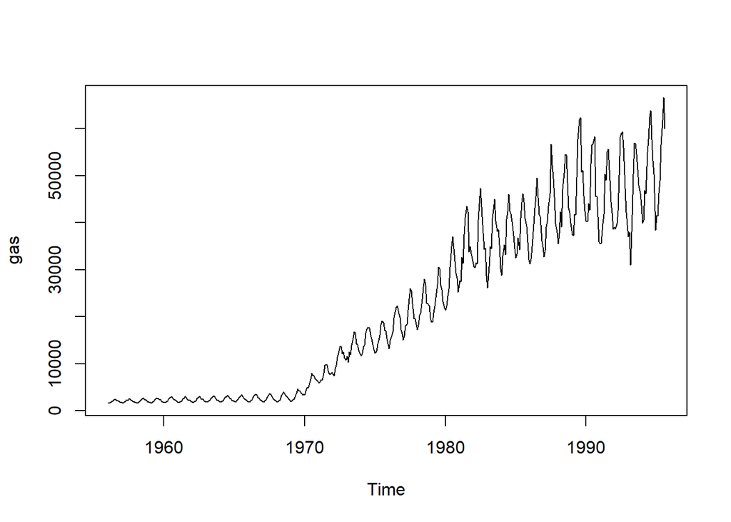

```r
data(gas)
# ----> 1. 정상성 만족여부 확인 및 변환 (정상화)
plot(gas)  # 전체적인 모습 증가추세, 계절성 --> 정상성 아님
```

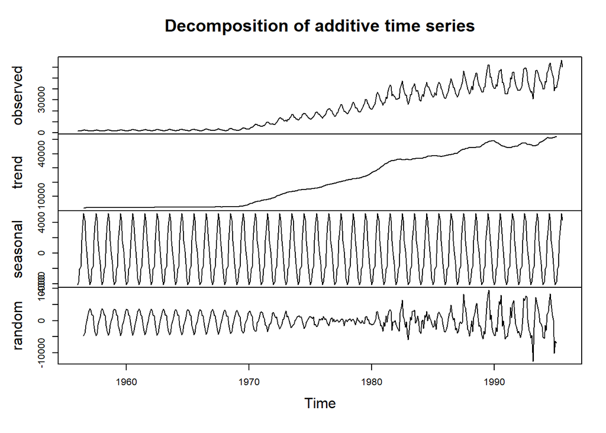

```r
# 평균 불일정(증가) 분산이 시점에 따라 다름 --> 정상성 아님
plot(decompose(gas))       # 시계열 데이터 분해
```

```r
adf.test(gas)              # adf 테스트로 정상여부 검정
```

```
    Augmented Dickey-Fuller Test

data:  gas
Dickey-Fuller = -2.7131, Lag order = 7, p-value = 0.2764
alternative hypothesis: stationary
```

```r
   # p-value가 0.28로 귀무가설 기각 못함 --> 비정상 시계열임

ndiffs(gas)                # 차분은 1하면 된다네..
```

```
[1] 1
```

```r
gas.diff <- diff(gas)      # 차분해보자.
adf.test(gas.diff)         # 차분한 데이터는 정상성 만족하네..
```

```
    Augmented Dickey-Fuller Test

data:  gas.diff
Dickey-Fuller = -19.321, Lag order = 7, p-value = 0.01
alternative hypothesis: stationary
```

```r
gas.log <- log(gas)        # 로그변환하자
adf.test(gas.log)          # 로그변환해도 정상성 아님
```

```
    Augmented Dickey-Fuller Test

data:  gas.log
Dickey-Fuller = -0.515, Lag order = 7, p-value = 0.9811
alternative hypothesis: stationary
```

```r
gas.log.diff <- diff(gas.log) # 로그변환한것을 차분하자
adf.test(diff(gas.log))    # 로그 변환한 데이터를 차분하니 정상성 만족
```

```
    Augmented Dickey-Fuller Test

data:  diff(gas.log)
Dickey-Fuller = -17.55, Lag order = 7, p-value = 0.01
alternative hypothesis: stationary
```

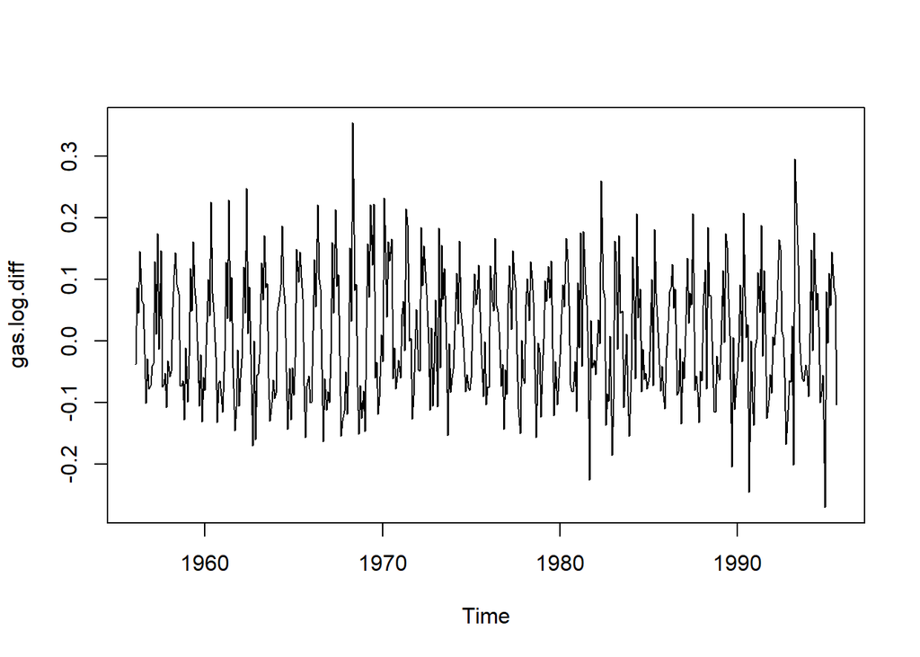

```r
plot(gas.log.diff)         # 만족하네.
```

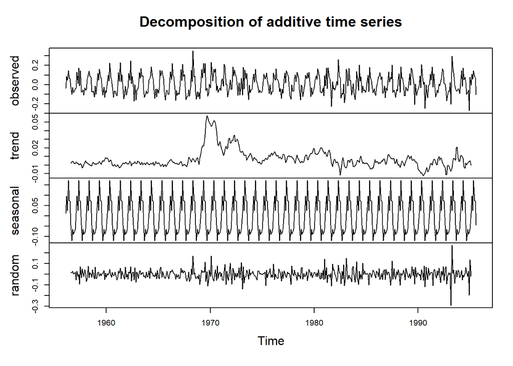

```r
plot(decompose(gas.log.diff))  # 추세선은 사라진것 확인
```

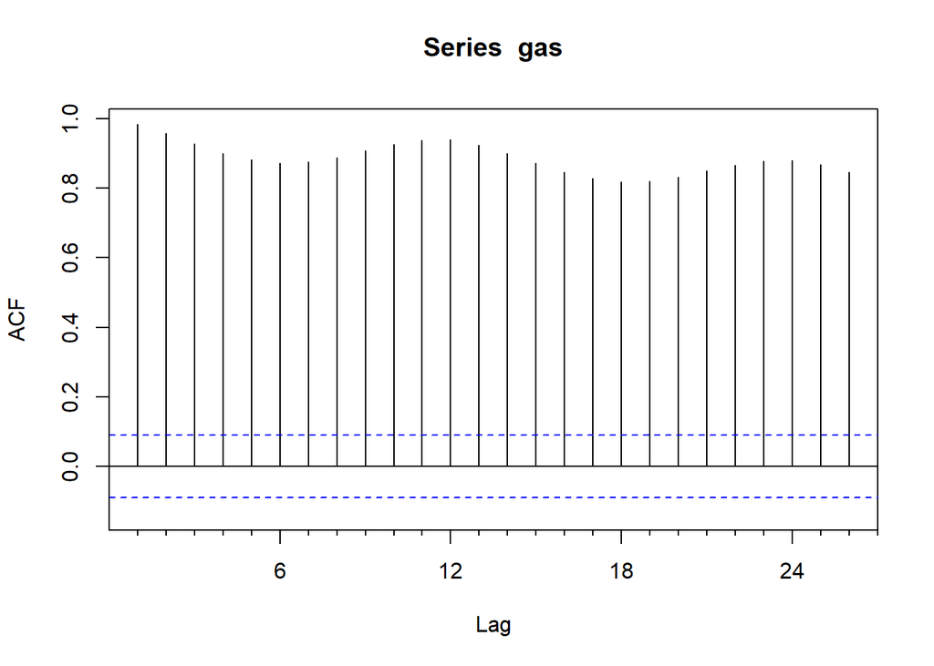

```r
# ---->>> ARIMA 예측모델 생성 : p,d,q 값 찾기
Acf(gas)           # 당연히 불가능하겠지.
```

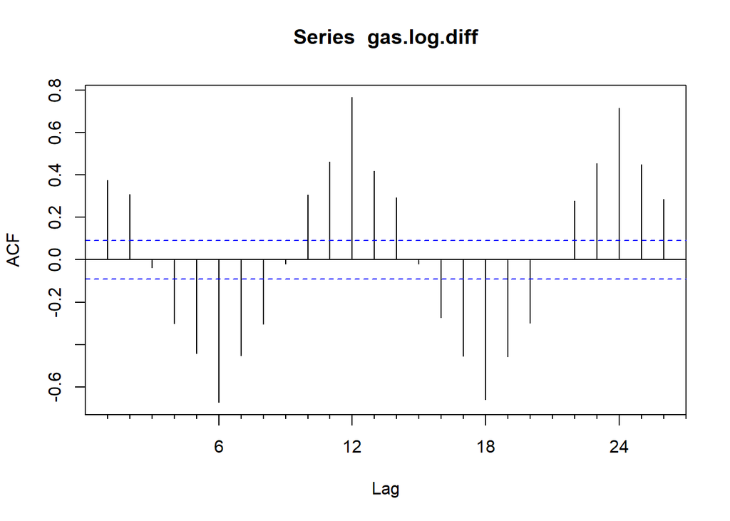

```r
Acf(gas.log.diff)  # 변환및 차분한 데이터도 자기상관이  0으로 수렴안함
```

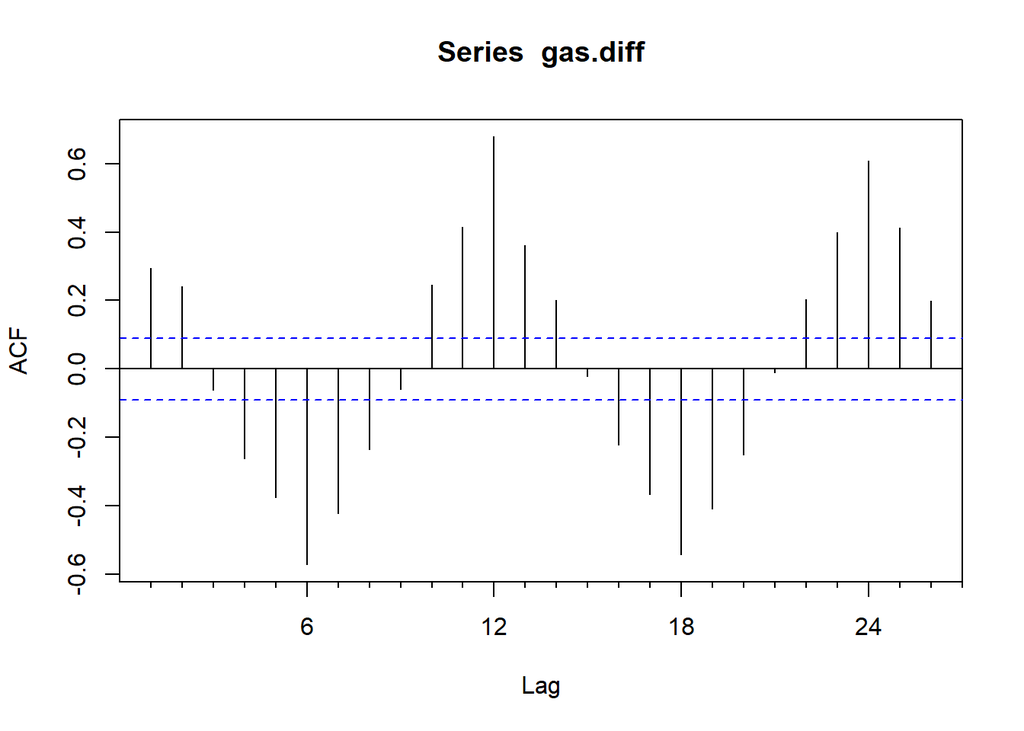

```r
Acf(gas.diff)      #
```

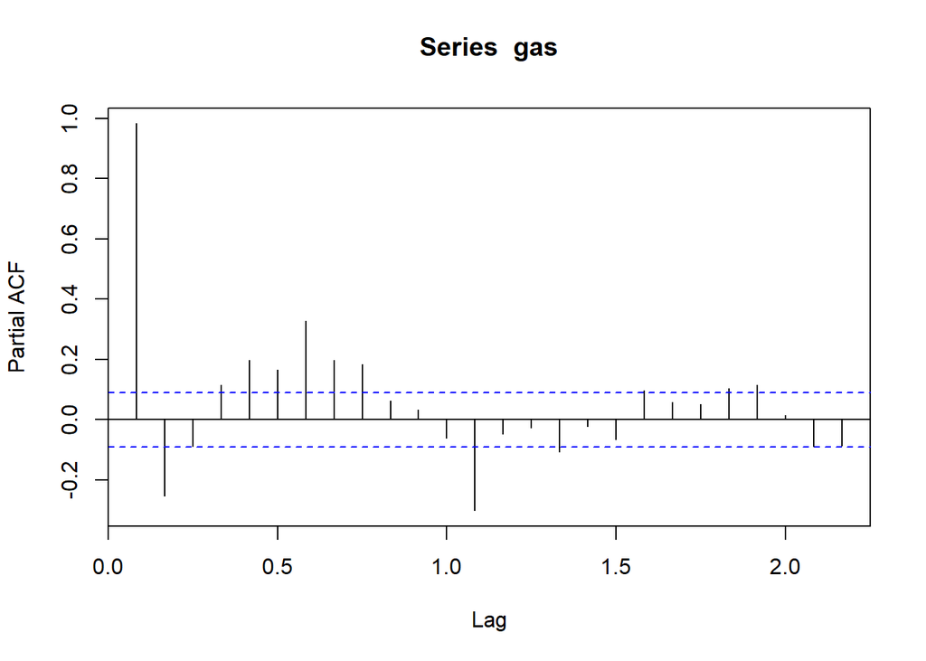

```r
pacf(gas)          #
```

```r
# ACF PACF로 찾기가 p,q 찾기 어려우니 원래 데이터로 auto.arima로 하자
arima.auto <- auto.arima(gas)
arima.auto    # ARIMA(2,1,1)(0,1,1)[12] 가 된다네.
```

```
Series: gas
ARIMA(2,1,1)(0,1,1)[12]

Coefficients:
         ar1     ar2      ma1     sma1
      0.3756  0.1457  -0.8620  -0.6216
s.e.  0.0780  0.0621   0.0571   0.0376

sigma^2 estimated as 2587081:  log likelihood=-4076.58
AIC=8163.16   AICc=8163.29   BIC=8183.85
```

```r
# 비계절성 : p=2, d=1, q= 1   계절성 : p=0,d=1,q=1,  12개월
# 이 결과는 결국 아래와 동일한 결과가 나온다.
arima(gas, order = c(2,1,1),
           seasonal = list(order=c(0,1,1),
           period = 12))     # ---> 이게 결국 SARIMA 아닐까??
```

```
Call:
arima(x = gas, order = c(2, 1, 1), seasonal = list(order = c(0, 1, 1), period = 12))

Coefficients:
         ar1     ar2      ma1     sma1
      0.3756  0.1457  -0.8620  -0.6216
s.e.  0.0780  0.0621   0.0571   0.0376

sigma^2 estimated as 2564730:  log likelihood = -4076.58,  aic = 8163.16
```

```r
accuracy(arima.auto)   # 모형의 정확도는 보는바와 같다.
```

```
                   ME     RMSE      MAE      MPE     MAPE      MASE        ACF1
Training set 27.72266 1579.457 893.4504 0.272275 3.900233 0.4789312 0.002271673
```

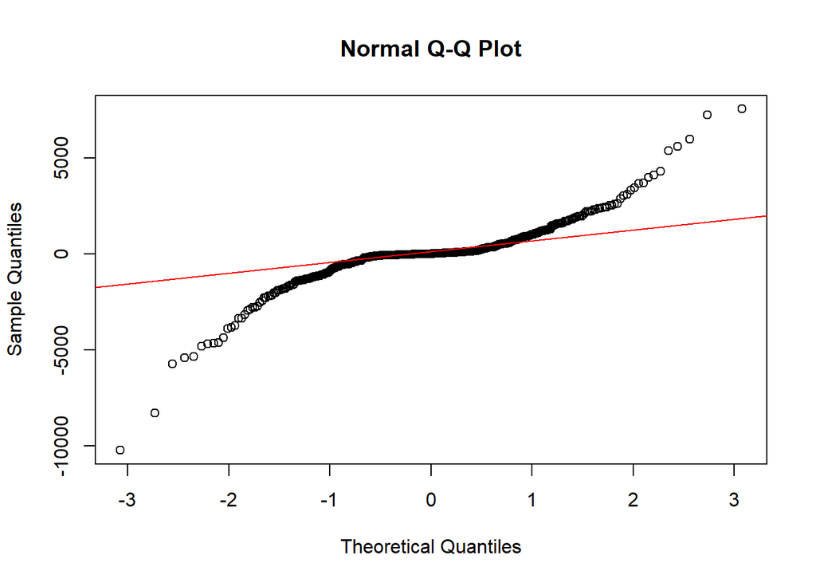

```r
# 이제 fitting된 모형이 가정을 만족하는지 보자.
# 1. 잔차의 정규성 : QQplot
qqnorm(arima.auto$residuals)    # 정규분포는 따르지 않네..
qqline(arima.auto$residuals, col ="red")
```

```r
shapiro.test(arima.auto$residuals)  # shapiro 검정해도. 마찬가지
```

```
    Shapiro-Wilk normality test

data:  arima.auto$residuals
W = 0.83248, p-value < 2.2e-16
```

```r
# 2. 잔차의 자기상관성 검정
Box.test(arima.auto$residuals, type = "Ljung-Box")
```

```
    Box-Ljung test

data:  arima.auto$residuals
X-squared = 0.0024719, df = 1, p-value = 0.9603
```

```r
# 자기상관이 0이라는 귀무가설을 기각하지 않음 즉 자기상관 없음
```

```r
#---->>>> 마지막으로 생성된 모형으로 예측을 해보자.
forecast(arima.auto, h = 5*12 )       # 예측
```

```
         Point Forecast    Lo 80    Hi 80    Lo 95    Hi 95
Sep 1995       56907.83 54846.53 58969.13 53755.35 60060.32
Oct 1995       52476.28 50158.98 54793.57 48932.28 56020.27
Nov 1995       49719.79 47202.83 52236.76 45870.42 53569.16
Dec 1995       43473.70 40830.29 46117.11 39430.96 47516.45
Jan 1996       43318.41 40575.77 46061.05 39123.91 47512.91
Feb 1996       43601.71 40776.80 46426.62 39281.38 47922.04
Mar 1996       46668.11 43770.45 49565.78 42236.52 51099.71
Apr 1996       49376.36 46411.96 52340.76 44842.70 53910.02
May 1996       57536.25 54509.03 60563.46 52906.53 62165.97
Jun 1996       62184.69 59097.40 65271.98 57463.09 66906.29
Jul 1996       65795.74 62650.40 68941.08 60985.35 70606.13
Aug 1996       63391.54 60189.71 66593.37 58494.76 68288.31
Sep 1996       58754.82 55269.44 62240.20 53424.39 64085.24
Oct 1996       54366.83 50741.76 57991.89 48822.76 59910.89
Nov 1996       51409.56 47657.70 55161.41 45671.58 57147.53
Dec 1996       45094.41 41235.96 48952.85 39193.43 50995.38
Jan 1997       44883.92 40928.31 48839.53 38834.34 50933.51
Feb 1997       45136.43 41090.38 49182.48 38948.54 51324.33
Mar 1997       48183.23 44051.18 52315.28 41863.81 54502.66
Apr 1997       50879.63 46664.82 55094.44 44433.64 57325.63
May 1997       59032.21 54737.12 63327.30 52463.44 65600.98
Jun 1997       63676.18 59302.82 68049.55 56987.70 70364.66
Jul 1997       67284.49 62834.55 71734.43 60478.89 74090.09
Aug 1997       64878.61 60353.58 69403.64 57958.17 71799.05
Sep 1997       60240.86 55441.20 65040.51 52900.42 67581.29
Oct 1997       55852.23 50899.84 60804.63 48278.19 63426.27
Nov 1997       52894.57 47800.89 57988.26 45104.45 60684.70
Dec 1997       46579.19 41362.71 51795.66 38601.28 54557.09
Jan 1998       46368.56 41038.19 51698.93 38216.46 54520.66
Feb 1998       46620.98 41183.20 52058.76 38304.62 54937.34
Mar 1998       49667.72 44126.94 55208.51 41193.82 58141.63
Apr 1998       52364.09 46723.58 58004.60 43737.67 60990.51
May 1998       60516.65 54778.98 66254.32 51741.64 69291.65
Jun 1998       65160.61 59327.91 70993.31 56240.27 74080.95
Jul 1998       68768.91 62843.00 74694.81 59706.02 77831.79
Aug 1998       66363.02 60345.54 72380.50 57160.08 75565.96
Sep 1998       61725.26 55437.09 68013.44 52108.33 71342.20
Oct 1998       57336.64 50884.49 63788.79 47468.93 67204.35
Nov 1998       54378.98 47773.22 60984.74 44276.34 64481.62
Dec 1998       48063.59 41321.28 54805.90 37752.12 58375.06
Jan 1999       47852.96 40982.48 54723.44 37345.47 58360.46
Feb 1999       48105.38 41112.93 55097.83 37411.35 58799.41
Mar 1999       51152.13 44041.98 58262.28 40278.10 62026.16
Apr 1999       53848.50 46623.90 61073.09 42799.43 64897.56
May 1999       62001.05 54664.59 69337.52 50780.90 73221.21
Jun 1999       66645.01 59198.84 74091.19 55257.08 78032.95
Jul 1999       70253.31 62699.31 77807.31 58700.47 81806.15
Aug 1999       67847.43 60187.30 75507.56 56132.27 79562.58
Sep 1999       63209.67 55279.97 71139.37 51082.24 75337.10
Oct 1999       58821.04 50717.34 66924.75 46427.50 71214.59
Nov 1999       55863.39 47595.17 64131.60 43218.24 68508.53
Dec 1999       49548.00 41131.12 57964.87 36675.49 62420.50
Jan 2000       49337.37 40779.72 57895.02 36249.57 62425.16
Feb 2000       49589.79 40897.29 58282.29 36295.75 62883.83
Mar 2000       52636.53 43813.30 61459.77 39142.56 66130.51
Apr 2000       55332.90 46382.10 64283.70 41643.83 69021.96
May 2000       63485.46 54409.65 72561.27 49605.20 77365.71
Jun 2000       68129.42 58930.75 77328.09 54061.27 82197.57
Jul 2000       71737.72 62418.09 81057.35 57484.57 85990.86
Aug 2000       69331.83 59892.96 78770.70 54896.32 83767.34
```

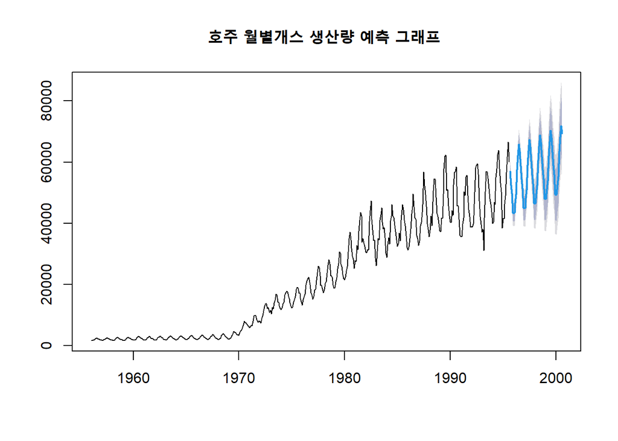

```r
plot(forecast(arima.auto, h = 5*12 ),
     main = "호주 월별개스 생산량 예측 그래프 ") # 예측 결과 플로팅
```